# Practical Machine Learning - Course Project

James R. Francisco

December 16, 2018

## Introduction

Using devices such as Jawbone Up, Nike FuelBand, and Fitbit it is now possible to collect a large amount of data about personal activity relatively inexpensively. These type of devices are part of the quantified self movement – a group of enthusiasts who take measurements about themselves regularly to improve their health, to find patterns in their behavior, or because they are tech geeks. One thing that people regularly do is quantify how much of a particular activity they do, but they rarely quantify how well they do it.

The goal of this research will be to use data from accelerometers on the belt, forearm, arm, and dumbell of 6 participants. They were asked to perform barbell lifts correctly and incorrectly in 5 different ways. More information is available from the website here: http://groupware.les.inf.puc-rio.br/har (see the section on the Weight Lifting Exercise Dataset).The data will be used to evaluate how well they did the exercises.

## Data Loading

The data files were imported directly from the course archives. In this step, the files are loaded into the R Studio environment. The packages that will be used for the analysis are also loaded here.

```r
library(caret)
library(rpart)
library(rpart.plot)
library(RColorBrewer)
library(rattle)
library(randomForest)
library(gbm)
trainData <- read.csv('./pml-training.csv', header=T)
validData <- read.csv('./pml-testing.csv', header=T)
```

```r
dim(trainData)
```

```
## [1] 19622   160
```

```r
dim(validData)
```

```
## [1]  20 160
```

## Data Preparation

```r
indColToRemove <- which(colSums(is.na(trainData) |trainData=="")>0.9*dim(trainData)[1])
trainDataClean <- trainData[,-indColToRemove]
trainDataClean <- trainDataClean[,-c(1:7)]
dim(trainDataClean)
```

```
## [1] 19622    53
```

```r
indColToRemove <- which(colSums(is.na(validData) |validData=="")>0.9*dim(validData)[1])
validDataClean <- validData[,-indColToRemove]
validDataClean <- validDataClean[,-1]
dim(validDataClean)
```

```
## [1] 20 59
```

This phase of data preparation reduces the number of columns from 160 to 53.

## Training Data Partitioning and partitioning

In order to prepare the data for prediction, the original training data is partitioned in order to allow cross-validation and compute the out of sample error.

```r
set.seed(1234)
inTrain <- createDataPartition(trainDataClean$classe, p = 0.7, list = FALSE)
trainData1 <- trainDataClean[inTrain, ]
testData <- trainDataClean[-inTrain, ]
dim(trainData1)
```

```
## [1] 13737    53
```

```r
dim(testData)
```

```
## [1] 5885   53
```

For the analysis of this data, we will test 3 different models : * classification tree * random forest * gradient boosting method

## Classification Tree evaluation

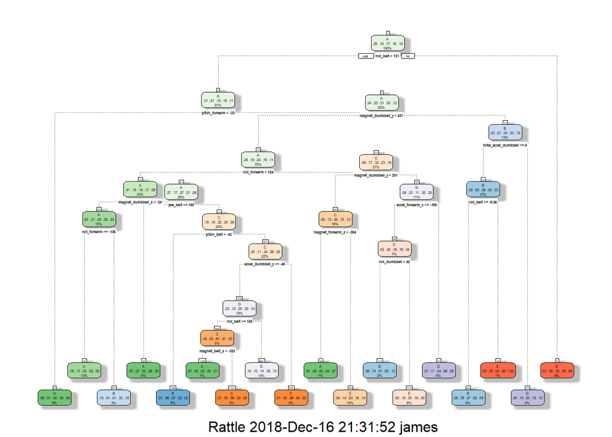

```r
set.seed(12345)
decisionTreeMod1 <- rpart(classe ~ ., data=trainData1, method="class")
fancyRpartPlot(decisionTreeMod1)
```

the “decisionTreeModel” is vaidated on the testData to find out how well it performs by looking at the accuracy variable.

```r
predictTreeMod1 <- predict(decisionTreeMod1, testData, type = "class")
cmtree <- confusionMatrix(predictTreeMod1, testData$classe)
cmtree
```

```
## Confusion Matrix and Statistics
##
##           Reference
## Prediction    A    B    C    D    E
##          A 1364  169   24   48   16
##          B   60  581   46   79   74
##          C   52  137  765  129  145
##          D  183  194  125  650  159
##          E   15   58   66   58  688
##
## Overall Statistics
##
##                Accuracy : 0.6879
##                  95% CI : (0.6758, 0.6997)
##     No Information Rate : 0.2845
##     P-Value [Acc > NIR] : < 2.2e-16
##
##                   Kappa : 0.6066
##  Mcnemar's Test P-Value : < 2.2e-16
##
## Statistics by Class:
##
##                      Class: A Class: B Class: C Class: D Class: E
## Sensitivity            0.8148  0.51010   0.7456   0.6743   0.6359
## Specificity            0.9390  0.94543   0.9047   0.8657   0.9590
## Pos Pred Value         0.8415  0.69167   0.6230   0.4958   0.7774
## Neg Pred Value         0.9273  0.88940   0.9440   0.9314   0.9212
## Prevalence             0.2845  0.19354   0.1743   0.1638   0.1839
## Detection Rate         0.2318  0.09873   0.1300   0.1105   0.1169
## Detection Prevalence   0.2754  0.14274   0.2087   0.2228   0.1504
## Balanced Accuracy      0.8769  0.72776   0.8252   0.7700   0.7974
```

We can notice that the accuracy of this first model is very low (about 69%). This means that the outcome class will not be predicted very well by the other predictors. Plotting the results shows the issue clearly.

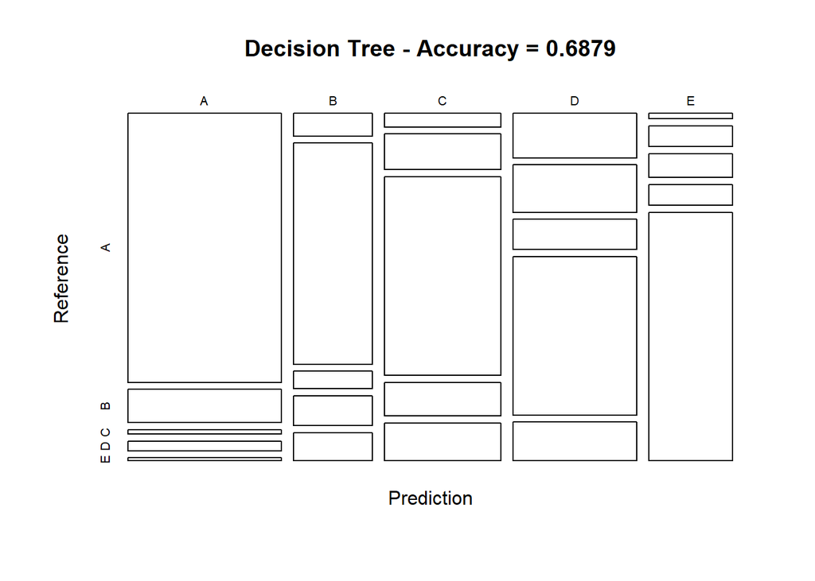

```r
plot(cmtree$table, col = cmtree$byClass,
     main = paste("Decision Tree - Accuracy =", round(cmtree$overall['Accuracy'], 4)))
```

## Random Forest evaluation

```r
controlRF <- trainControl(method="cv", number=3, verboseIter=FALSE)
modRF1 <- train(classe ~ ., data=trainData1, method="rf", trControl=controlRF)
modRF1$finalModel
```

```
##
## Call:
##  randomForest(x = x, y = y, mtry = param$mtry)
##                Type of random forest: classification
##                      Number of trees: 500
## No. of variables tried at each split: 27
##
##         OOB estimate of  error rate: 0.61%
## Confusion matrix:
##      A    B    C    D    E class.error
## A 3902    3    0    0    1 0.001024066
## B   19 2633    6    0    0 0.009405568
## C    0   11 2380    5    0 0.006677796
## D    0    0   25 2225    2 0.011989343
## E    0    0    4    8 2513 0.004752475
```

We then validate the model obtained model “modRF1” on the test data to find out how well it performs by looking at the Accuracy variable.

```r
predictRF1 <- predict(modRF1, newdata=testData)
cmrf <- confusionMatrix(predictRF1, testData$classe)
cmrf
```

```
## Confusion Matrix and Statistics
##
##           Reference
## Prediction    A    B    C    D    E
##          A 1674   10    0    0    0
##          B    0 1128    4    2    1
##          C    0    1 1018    6    1
##          D    0    0    4  955    3
##          E    0    0    0    1 1077
##
## Overall Statistics
##
##                Accuracy : 0.9944
##                  95% CI : (0.9921, 0.9961)
##     No Information Rate : 0.2845
##     P-Value [Acc > NIR] : < 2.2e-16
##
##                   Kappa : 0.9929
##  Mcnemar's Test P-Value : NA
##
## Statistics by Class:
##
##                      Class: A Class: B Class: C Class: D Class: E
## Sensitivity            1.0000   0.9903   0.9922   0.9907   0.9954
## Specificity            0.9976   0.9985   0.9984   0.9986   0.9998
## Pos Pred Value         0.9941   0.9938   0.9922   0.9927   0.9991
## Neg Pred Value         1.0000   0.9977   0.9984   0.9982   0.9990
## Prevalence             0.2845   0.1935   0.1743   0.1638   0.1839
## Detection Rate         0.2845   0.1917   0.1730   0.1623   0.1830
## Detection Prevalence   0.2862   0.1929   0.1743   0.1635   0.1832
## Balanced Accuracy      0.9988   0.9944   0.9953   0.9946   0.9976
```

The accuracy rate using the random forest is very high: Accuracy : 0.9944 and therefore the out-of-sample-error is equal to 0.0056.If we plot the model we get:

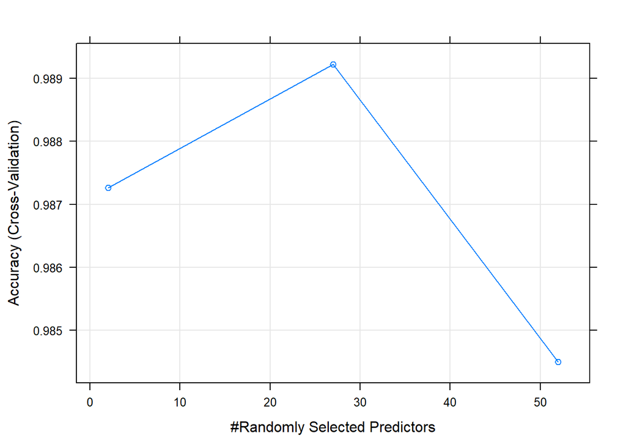

```r
plot(modRF1)
```

## Generalized Boosted Regression Model evaluation

Another approach to a predictive model is to use a generalized boosted model (GBM). In this approach we use 5-fold reampling with one repetition.

```r
set.seed(12345)
controlGBM <- trainControl(method = "repeatedcv", number = 5, repeats = 1)
modGBM  <- train(classe ~ ., data=trainData1, method = "gbm", trControl = controlGBM, verbose = FALSE)
modGBM$finalModel
```

```
## A gradient boosted model with multinomial loss function.
## 150 iterations were performed.
## There were 52 predictors of which 42 had non-zero influence.
```

```r
# print model summary
print(modGBM)
```

```
## Stochastic Gradient Boosting
##
## 13737 samples
##    52 predictor
##     5 classes: 'A', 'B', 'C', 'D', 'E'
##
## No pre-processing
## Resampling: Cross-Validated (5 fold, repeated 1 times)
## Summary of sample sizes: 10990, 10991, 10989, 10990, 10988
## Resampling results across tuning parameters:
##
##   interaction.depth  n.trees  Accuracy   Kappa
##   1                   50      0.7510370  0.6845815
##   1                  100      0.8171350  0.7686429
##   1                  150      0.8533135  0.8144335
##   2                   50      0.8520032  0.8125199
##   2                  100      0.9071828  0.8825490
##   2                  150      0.9316429  0.9134984
##   3                   50      0.8950994  0.8671743
##   3                  100      0.9416893  0.9262125
##   3                  150      0.9619269  0.9518304
##
## Tuning parameter 'shrinkage' was held constant at a value of 0.1
##
## Tuning parameter 'n.minobsinnode' was held constant at a value of 10
## Accuracy was used to select the optimal model using the largest value.
## The final values used for the model were n.trees = 150,
##  interaction.depth = 3, shrinkage = 0.1 and n.minobsinnode = 10.
```

Validation of the training data against the test partition reports the accuracy of this model.

```r
predictGBM <- predict(modGBM, newdata=testData)
cmGBM <- confusionMatrix(predictGBM, testData$classe)
cmGBM
```

```
## Confusion Matrix and Statistics
##
##           Reference
## Prediction    A    B    C    D    E
##          A 1655   45    0    1    1
##          B   10 1069   27    4   20
##          C    4   24  985   24    9
##          D    4    1   11  924   16
##          E    1    0    3   11 1036
##
## Overall Statistics
##
##                Accuracy : 0.9633
##                  95% CI : (0.9582, 0.968)
##     No Information Rate : 0.2845
##     P-Value [Acc > NIR] : < 2.2e-16
##
##                   Kappa : 0.9535
##  Mcnemar's Test P-Value : 6.099e-09
##
## Statistics by Class:
##
##                      Class: A Class: B Class: C Class: D Class: E
## Sensitivity            0.9886   0.9385   0.9600   0.9585   0.9575
## Specificity            0.9888   0.9871   0.9874   0.9935   0.9969
## Pos Pred Value         0.9724   0.9460   0.9417   0.9665   0.9857
## Neg Pred Value         0.9955   0.9853   0.9915   0.9919   0.9905
## Prevalence             0.2845   0.1935   0.1743   0.1638   0.1839
## Detection Rate         0.2812   0.1816   0.1674   0.1570   0.1760
## Detection Prevalence   0.2892   0.1920   0.1777   0.1624   0.1786
## Balanced Accuracy      0.9887   0.9628   0.9737   0.9760   0.9772
```

The accuracy rate using the GBM approach is very high: Accuracy : 0.9633 and therefore the out-of-sample-error is equal to 0.0367. as good as that is, the Random Forest model is significantly more accurate, Therefore, the Random Forest model will be applied to the sample test data.

## Random Forest modeling of the validation data

```r
Results <- predict(modRF1, newdata=validDataClean)
Results
```

```
##  [1] B A B A A E D B A A B C B A E E A B B B
## Levels: A B C D E
```

This result set will be used as the answers in the “Course Project Prediction Quiz”